# Week 03: Ensemble Learning & Random Forests

# Part 7: Random Forests for Regression

Random Forests work equally well for **regression** tasks. Instead of voting on class labels, trees average their numerical predictions. Node impurity is measured by **MSE** instead of Gini/Entropy.

$$\hat{y}(x) = \frac{1}{B} \sum_{b=1}^{B}
T_b(x)$$

```r
data(mtcars)
set.seed(MASTER_SEED)

# Predict mpg from car attributes
tr_idx <- sample(1:nrow(mtcars), 22)
mtcars_train <- mtcars[tr_idx, ]
mtcars_test  <- mtcars[-tr_idx, ]

# Compare: single tree vs random forest
single_reg <- rpart(mpg ~ ., data = mtcars_train, control = rpart.control(maxdepth = 3))
rf_reg     <- randomForest(mpg ~ ., data = mtcars_train, ntree = 500, importance = TRUE)

pred_single <- predict(single_reg, mtcars_test)
pred_rf     <- predict(rf_reg,     mtcars_test)

rmse <- function(y, yhat) sqrt(mean((y - yhat)^2))

cat(sprintf("Single Tree RMSE : %.3f mpg\n", rmse(mtcars_test$mpg, pred_single)))
```

```
## Single Tree RMSE : 3.755 mpg
```

```r
cat(sprintf("Random Forest RMSE: %.3f mpg\n", rmse(mtcars_test$mpg, pred_rf)))
```

```
## Random Forest RMSE: 2.297 mpg
```

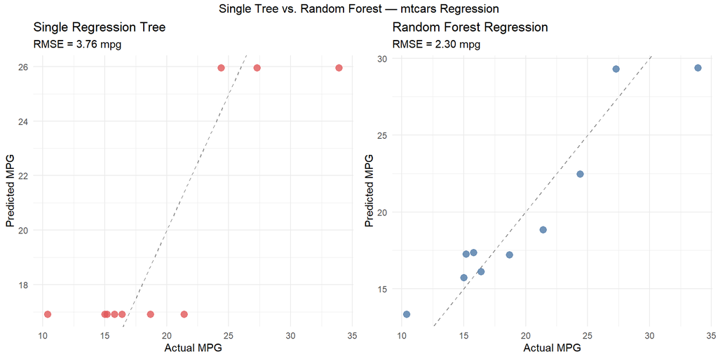

```r
# Side-by-side predicted vs actual
plot_df <- data.frame(
  actual     = mtcars_test$mpg,
  tree_pred  = pred_single,
  rf_pred    = pred_rf
)

p_tree <- ggplot(plot_df, aes(x = actual, y = tree_pred)) +
  geom_abline(slope = 1, intercept = 0, linetype = "dashed", color = "grey50") +
  geom_point(color = "#E15759", size = 3, alpha = 0.8) +
  labs(title = "Single Regression Tree",
       subtitle = sprintf("RMSE = %.2f mpg", rmse(mtcars_test$mpg, pred_single)),
       x = "Actual MPG", y = "Predicted MPG") +
  theme_minimal()

p_rf <- ggplot(plot_df, aes(x = actual, y = rf_pred)) +
  geom_abline(slope = 1, intercept = 0, linetype = "dashed", color = "grey50") +
  geom_point(color = "#4E79A7", size = 3, alpha = 0.8) +
  labs(title = "Random Forest Regression",
       subtitle = sprintf("RMSE = %.2f mpg", rmse(mtcars_test$mpg, pred_rf)),
       x = "Actual MPG", y = "Predicted MPG") +
  theme_minimal()

grid.arrange(p_tree, p_rf, ncol = 2,
  top = "Single Tree vs. Random Forest — mtcars Regression")
```

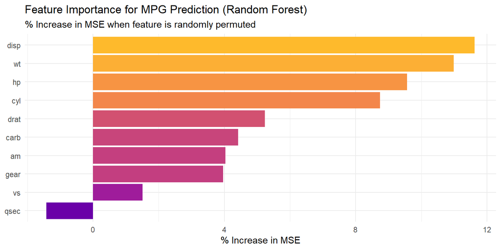

```r
imp_reg <- importance(rf_reg)
imp_reg_df <- as.data.frame(imp_reg) %>%
  rownames_to_column("Feature") %>%
  arrange(desc(`%IncMSE`))

ggplot(imp_reg_df, aes(x = reorder(Feature, `%IncMSE`), y = `%IncMSE`, fill = `%IncMSE`)) +
  geom_col() +
  coord_flip() +
  scale_fill_viridis_c(option = "plasma", begin = 0.2, end = 0.85) +
  labs(
    title = "Feature Importance for MPG Prediction (Random Forest)",
    subtitle = "% Increase in MSE when feature is randomly permuted",
    x = NULL, y = "% Increase in MSE"
  ) +
  theme_minimal() +
  theme(legend.position = "none")
```

# Part 8: Boosting — Sequential Ensemble Methods

Bagging and Random Forests build trees **in parallel** on independent bootstrap samples. **Boosting** takes a fundamentally different approach: trees are built **sequentially**, each one trying to correct the errors of the previous one **[1]**.

## 8.1 AdaBoost — Adaptive Boosting

AdaBoost focuses subsequent learners on the **hard examples** (those the previous learner got wrong) by re-weighting training instances.

**Algorithm:**

1. Initialize all instance weights: $w_i = \frac{1}{m}$
2. Train a weak learner, compute weighted error $r_j$
3. Compute learner weight: $\alpha_j = \eta \log\left(\frac{1 - r_j}{r_j}\right)$
4. Boost misclassified instance weights: $w_i \leftarrow w_i \cdot \exp(\alpha_j)$
5. Normalize weights, repeat

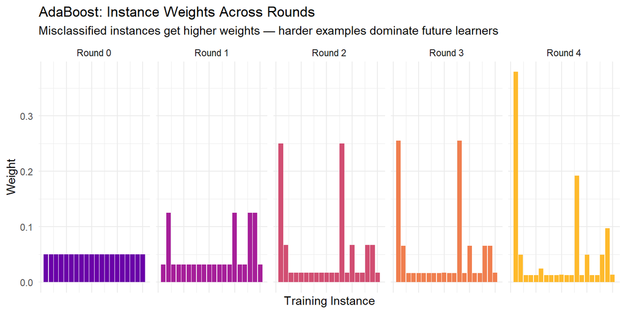

```r
# Simulate AdaBoost weight evolution
set.seed(MASTER_SEED)
n_obs <- 20
true_labels <- rep(c(1, -1), each = 10)
weights <- rep(1/n_obs, n_obs)

weight_history <- matrix(NA, nrow = 5, ncol = n_obs)
weight_history[1, ] <- weights

for (round in 1:4) {
  # Weighted sampling: higher-weight instances are more likely to be misclassified
  # (weak learner trained on weighted data still gets some hard cases wrong)
  n_wrong <- sample(2:5, 1)
  wrong <- sample(1:n_obs, n_wrong, prob = weights, replace = FALSE)
  r_j <- sum(weights[wrong])
  r_j <- max(min(r_j, 0.49), 0.01)
  alpha_j <- log((1 - r_j) / r_j)
  weights[wrong] <- weights[wrong] * exp(alpha_j)
  weights <- weights / sum(weights)
  weight_history[round + 1, ] <- weights
}

weight_df <- as.data.frame(weight_history) %>%
  mutate(round = 0:4) %>%
  pivot_longer(-round, names_to = "obs", values_to = "weight") %>%
  mutate(obs = as.integer(gsub("V", "", obs)))

ggplot(weight_df, aes(x = obs, y = weight, fill = factor(round))) +
  geom_col(position = "dodge") +
  facet_wrap(~paste("Round", round), nrow = 1) +
  scale_fill_viridis_d(option = "plasma", begin = 0.2, end = 0.85) +
  labs(
    title = "AdaBoost: Instance Weights Across Rounds",
    subtitle = "Misclassified instances get higher weights — harder examples dominate future learners",
    x = "Training Instance", y = "Weight"
  ) +
  theme_minimal() +
  theme(legend.position = "none", axis.text.x = element_blank())
```

## 8.2 Gradient Boosting

Gradient Boosting is more general than AdaBoost. Instead of re-weighting instances, it fits each new tree to the **residual errors** (pseudo-residuals) of the previous ensemble **[1]**.

$$F_m(x) = F_{m-1}(x) + \eta \cdot
h_m(x)$$

where $h_m$ is a weak learner fit to the negative gradient of the loss function.

The `learning_rate` ($\eta$) scales each tree’s contribution — lower = more trees needed, but better generalization (**shrinkage** regularization).

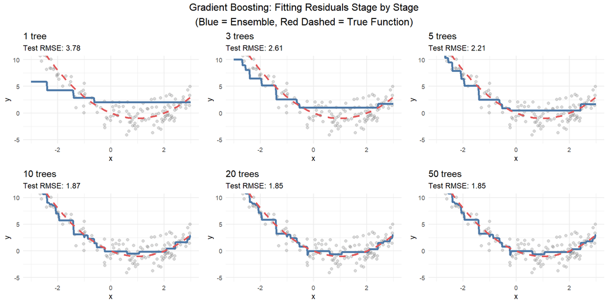

```r
set.seed(MASTER_SEED)

# Simulate a noisy quadratic function
n_pts <- 200
X_sim <- runif(n_pts, -3, 3)
y_sim <- X_sim^2 - 2 * X_sim + rnorm(n_pts, sd = 1.5)
sim_df <- data.frame(x = X_sim, y = y_sim)
train_sim <- sim_df[1:150, ]
test_sim  <- sim_df[151:200, ]

# Manual gradient boosting (MSE loss, residuals = negative gradient)
lr <- 0.3
trees <- list()
F_pred_train <- rep(mean(train_sim$y), nrow(train_sim))
F_pred_test  <- rep(mean(train_sim$y), nrow(test_sim))

stages <- c(1, 3, 5, 10, 20, 50)
stage_preds <- list()

for (m in 1:max(stages)) {
  residuals_m <- train_sim$y - F_pred_train
  tree_m <- rpart(residuals_m ~ x, data = train_sim,
                   control = rpart.control(maxdepth = 2, minsplit = 5))
  trees[[m]] <- tree_m
  F_pred_train <- F_pred_train + lr * predict(tree_m, train_sim)
  F_pred_test  <- F_pred_test  + lr * predict(tree_m, test_sim)
  if (m %in% stages) {
    stage_preds[[as.character(m)]] <- F_pred_test
  }
}

x_seq <- seq(-3, 3, length.out = 200)
plot_list <- lapply(names(stage_preds), function(s) {
  pred_vals <- stage_preds[[s]]
  rmse_s <- sqrt(mean((test_sim$y - pred_vals)^2))

  pred_curve_y <- rep(mean(train_sim$y), 200)
  F_curve <- rep(mean(train_sim$y), 200)
  for (t_m in trees[1:as.integer(s)]) {
    F_curve <- F_curve + lr * predict(t_m, data.frame(x = x_seq))
  }

  ggplot(train_sim, aes(x = x, y = y)) +
    geom_point(alpha = 0.3, size = 1.5, color = "grey50") +
    geom_line(data = data.frame(x = x_seq, y = F_curve),
              aes(x = x, y = y), color = "#4E79A7", linewidth = 1.2) +
    stat_function(fun = function(x) x^2 - 2*x, color = "#E15759",
                  linetype = "dashed", linewidth = 1) +
    labs(
      title = paste0(s, ifelse(s == 1, " tree", " trees")),
      subtitle = sprintf("Test RMSE: %.2f", rmse_s),
      x = "x", y = "y"
    ) +
    coord_cartesian(ylim = c(-5, 10)) +
    theme_minimal(base_size = 9)
})

do.call(grid.arrange, c(plot_list, ncol = 3,
  top = "Gradient Boosting: Fitting Residuals Stage by Stage\n(Blue = Ensemble, Red Dashed = True Function)"))
```

## 8.3 Gradient Boosting in R with `gbm`

```r
set.seed(MASTER_SEED)
iris_gbm <- iris
iris_gbm$Species_bin <- ifelse(iris$Species == "virginica", 1, 0)

gbm_fit <- gbm(
  Species_bin ~ Sepal.Length + Sepal.Width + Petal.Length + Petal.Width,
  data         = iris_gbm[train_idx, ],
  distribution = "bernoulli",
  n.trees      = 200,
  interaction.depth = 3,
  shrinkage    = 0.1,
  cv.folds     = 5,
  verbose      = FALSE
)

best_iter <- gbm.perf(gbm_fit, method = "cv", plot.it = FALSE)
cat("Best number of trees (CV):", best_iter)
```

```
## Best number of trees (CV): 43
```

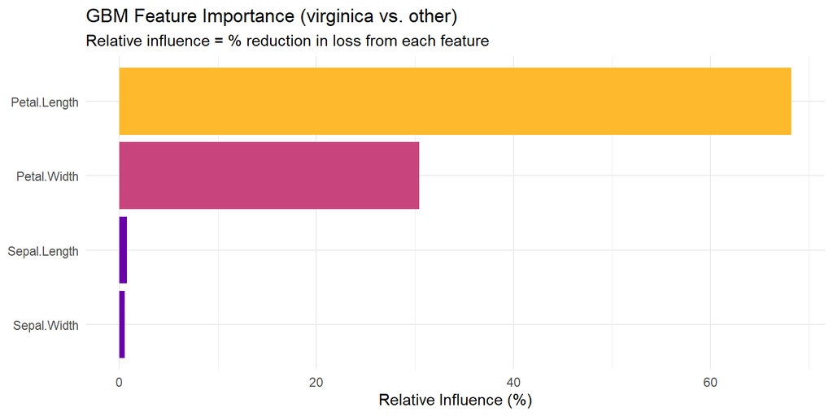

```r
# Feature importance from GBM
imp_gbm <- summary(gbm_fit, n.trees = best_iter, plotit = FALSE)
ggplot(imp_gbm, aes(x = reorder(var, rel.inf), y = rel.inf, fill = rel.inf)) +
  geom_col() +
  coord_flip() +
  scale_fill_viridis_c(option = "plasma", begin = 0.2, end = 0.85) +
  labs(
    title = "GBM Feature Importance (virginica vs. other)",
    subtitle = "Relative influence = % reduction in loss from each feature",
    x = NULL, y = "Relative Influence (%)"
  ) +
  theme_minimal() +
  theme(legend.position = "none")
```

## 8.4 Comparing Methods

```r
set.seed(MASTER_SEED)
# 5-fold CV comparison on iris (versicolor vs. other, binary)
iris_bin_df <- iris
iris_bin_df$target <- factor(ifelse(iris$Species == "versicolor", "yes", "no"))

folds <- cut(sample(1:150), breaks = 5, labels = FALSE)

cv_acc <- sapply(1:5, function(fold) {
  tr  <- iris_bin_df[folds != fold, ]
  te  <- iris_bin_df[folds == fold, ]

  # Single tree
  t_m <- rpart(target ~ Sepal.Length + Sepal.Width + Petal.Length + Petal.Width,
               data = tr, control = rpart.control(maxdepth = 4))
  acc_tree <- mean(predict(t_m, te, type = "class") == te$target)

  # Random Forest
  rf_m <- randomForest(target ~ Sepal.Length + Sepal.Width + Petal.Length + Petal.Width,
                        data = tr, ntree = 200)
  acc_rf <- mean(predict(rf_m, te) == te$target)

  c(tree = acc_tree, rf = acc_rf)
})

cv_results <- data.frame(
  Model    = c("Decision Tree", "Random Forest"),
  Mean_Acc = rowMeans(cv_acc),
  SD_Acc   = apply(cv_acc, 1, sd)
)

knitr::kable(cv_results, digits = 4,
  col.names = c("Model", "Mean CV Accuracy", "SD"),
  caption = "5-Fold CV Accuracy: Single Tree vs. Random Forest")
```

5-Fold CV Accuracy: Single Tree vs. Random Forest

|  | Model | Mean CV Accuracy | SD |
| --- | --- | --- | --- |
| tree | Decision Tree | 0.9267 | 0.0149 |
| rf | Random Forest | 0.9467 | 0.0183 |

# Part 9: Advantages, Disadvantages & When to Use What

## 9.1 Comparison Table

Ensemble Method Comparison

| Property | Decision Tree | Random Forest | Extra-Trees | Gradient Boosting |
| --- | --- | --- | --- | --- |
| Training speed | Fast | Moderate | Fast ✓ | Slow (sequential) |
| Prediction speed | Fast | Moderate | Moderate | Fast |
| Parallelizable | N/A | Yes ✓ | Yes ✓ | Partial |
| Handles overfitting | Poor (needs pruning) | Good ✓ | Better ✓ | Good (shrinkage) |
| Interpretable | High ✓ | Low ✗ | Low ✗ | Low ✗ |
| Feature importance | Yes (limited) | Yes ✓ | Yes ✓ | Yes ✓ |
| Works on small data | OK | OK | OK | OK |
| Handles missing values | Some (surrogates) | Some (OOB) | Some | Some |
| Hyperparameter sensitivity | Low | Low-Medium | Low | High ! |

## 9.2 When to Choose What

Practical Guide: When to Use Which Ensemble

| Scenario | Recommended Method |
| --- | --- |
| You need to explain the model to stakeholders | Single Decision Tree (or shallow RF) |
| You want the best out-of-the-box performance | Random Forest |
| Training time is limited | Extra-Trees (random thresholds = faster) |
| You have very noisy data | Random Forest (variance reduction handles noise) |
| You need to rank features | Random Forest (permutation importance is robust) |
| You want state-of-the-art on tabular data | Gradient Boosting / XGBoost (wins Kaggle) |

# Part 10: Stacking (Blending)

**Stacking** (stacked generalization) replaces the simple voting/averaging aggregation with a **trained meta-learner** **[1]**:

1. Split training data into K folds.
2. Train several diverse **base learners** on K-1 folds; predict on the held-out fold.
3. Collect all OOF (out-of-fold) predictions → create a **meta-feature matrix**.
4. Train a **meta-learner** (e.g., linear model, another RF) on the meta-features.

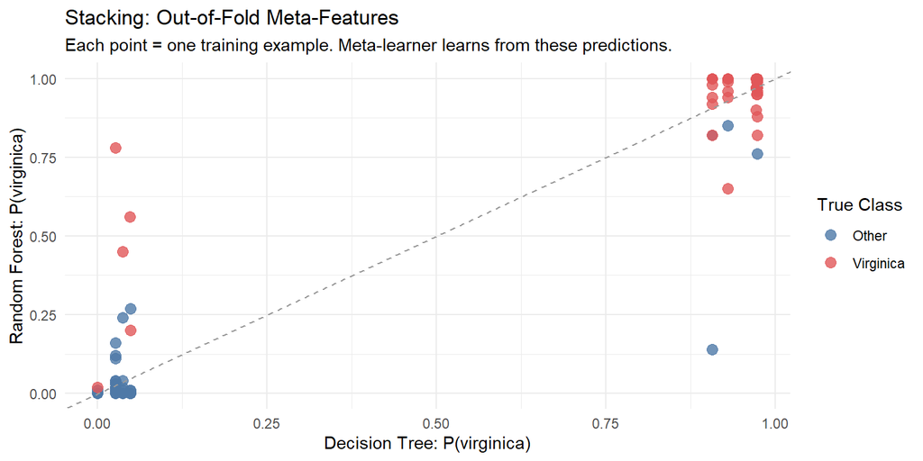

```r
set.seed(MASTER_SEED)
data(iris)
iris_bin2 <- iris
iris_bin2$target <- factor(ifelse(iris$Species == "virginica", 1, 0))

n <- nrow(iris_bin2)
k <- 5
fold_ids <- sample(rep(1:k, length.out = n))

meta_features <- matrix(NA, nrow = n, ncol = 2)
colnames(meta_features) <- c("tree_prob", "rf_prob")

for (f in 1:k) {
  tr <- iris_bin2[fold_ids != f, ]
  te <- iris_bin2[fold_ids == f, ]

  t_m <- rpart(target ~ Sepal.Length + Sepal.Width + Petal.Length + Petal.Width,
               data = tr, control = rpart.control(maxdepth = 3))
  rf_m <- randomForest(target ~ Sepal.Length + Sepal.Width + Petal.Length + Petal.Width,
                        data = tr, ntree = 100)

  meta_features[fold_ids == f, "tree_prob"] <- predict(t_m, te, type = "prob")[, "1"]
  meta_features[fold_ids == f, "rf_prob"]   <- predict(rf_m, te, type = "prob")[, "1"]
}

meta_df <- as.data.frame(meta_features)
meta_df$target <- iris_bin2$target

ggplot(meta_df, aes(x = tree_prob, y = rf_prob, color = target)) +
  geom_point(size = 3, alpha = 0.8) +
  geom_abline(slope = 1, intercept = 0, linetype = "dashed", color = "grey60") +
  scale_color_manual(values = c("0" = "#4E79A7", "1" = "#E15759"),
                     labels = c("0" = "Other", "1" = "Virginica")) +
  labs(
    title = "Stacking: Out-of-Fold Meta-Features",
    subtitle = "Each point = one training example. Meta-learner learns from these predictions.",
    x = "Decision Tree: P(virginica)", y = "Random Forest: P(virginica)",
    color = "True Class"
  ) +
  theme_minimal()
```

> **Note:** The meta-features from each base learner become the **inputs** to the meta-learner (blender). In practice, you’d train a simple logistic regression or another RF on `meta_df` to produce the final ensemble prediction.

# Knowledge Check

**Question 1:** Why does averaging many trees reduce variance but not bias?**

**Answer:** Each tree is an unbiased estimator of the true function (in expectation). Averaging $B$ independent estimates: $\text{Var}(\bar{y}) = \text{Var}(y)/B$ — variance shrinks with more trees, but the average of unbiased estimators is still unbiased. In practice, trees are positively correlated (same data), so the variance reduction is $\rho\sigma^2 + \frac{1-\rho}{B}\sigma^2$ — correlation $\rho$ limits reduction. Random feature subsets reduce $\rho$, hence further reduce variance **[2]**.

**Question 2:** You have trained 5 models all achieving 95% precision on the same training data. Can combining them improve results?**

**Answer:** Possibly, but only if they make **different errors**. If trained on the same data with similar algorithms, they will likely make the same mistakes, and voting won’t help. Diversity is key. To create useful ensembles: use different algorithms, train on different data subsets (bagging), or use different feature subsets. If all 5 are identical, the ensemble is no better than a single model **[1]**.

**Question 3:** What is Out-of-Bag evaluation and why is it useful?**

**Answer:** Each bootstrap sample leaves out ~37% of training instances (OOB instances). Each tree can be evaluated on its own OOB instances — data it never saw during training. Averaging these evaluations gives an unbiased estimate of generalization error without needing a separate validation set. This means you can use 100% of your data for training while still getting a cross-validation-like estimate **[1]**.

**Question 4:** What makes Extra-Trees more random than Random Forests, and when might they be preferred?**

**Answer:** Random Forests randomly select features at each node but still search for the **optimal threshold** for the chosen features. Extra-Trees also draw thresholds **randomly** from the feature’s range. This extreme randomness: (1) further decorrelates trees → lower variance, (2) eliminates expensive threshold search → much faster training. Extra-Trees may outperform RF when data is very noisy (more regularization helps) and are preferred when training speed matters **[1]**.

**Question 5:** When should you use Gradient Boosting instead of Random Forest?**

**Answer:** Gradient Boosting often achieves higher predictive accuracy on structured/tabular data — it’s the go-to method for Kaggle competitions. However, it (1) trains sequentially and cannot be easily parallelized, (2) is more sensitive to hyperparameters (learning rate, n_estimators, max_depth), and (3) can overfit if not regularized. Use GBM/XGBoost when accuracy is paramount and you can afford tuning time. Use Random Forest when you need a reliable, fast, and robust baseline **[2]**.

**Question 6:** Can a Random Forest overfit? How do you detect and fix it?**

**Answer:** Yes, but it’s harder to overfit than a single tree. Signs: large gap between OOB error and training accuracy. Fixes: (1) increase `nodesize` (larger minimum leaf → shallower trees), (2) decrease `maxnodes` (limit leaf count), (3) increase `mtry` (consider more features, more competition → less overfitting in some cases), (4) reduce `ntree` slightly if computation allows, (5) use OOB error curve to confirm trees have converged **[1][2]**.

# Summary

In this tutorial, we built from the instability problem of a single Decision Tree to a full ensemble framework:

[output not shown]

**The Big Picture:** Random Forests are one of the most reliable out-of-the-box algorithms in machine learning — they handle high dimensionality, mixed feature types, and noisy data with minimal hyperparameter tuning. Understanding them deeply (bagging, decorrelation, OOB, importance) builds the foundation for understanding gradient boosting and other advanced ensembles.

# References

[1] A. Géron, *Hands-On Machine Learning with Scikit-Learn, Keras, and TensorFlow*, 2nd ed. Sebastopol, CA: O’Reilly Media, 2019, ch. 7.

[2] B. C. Boehmke and B. M. Greenwell, *Hands-On Machine Learning with R*. Boca Raton, FL: CRC Press, 2020, ch. 10–11. [Online]. Available: https://bradleyboehmke.github.io/HOML/

[3] L. Breiman, “Bagging Predictors,” *Machine Learning*, vol. 24, no. 2, pp. 123–140, 1996.

[4] L. Breiman, “Random Forests,” *Machine Learning*, vol. 45, no. 1, pp. 5–32, 2001.

[5] P. Geurts, D. Ernst, and L. Wehenkel, “Extremely Randomized Trees,” *Machine Learning*, vol. 63, no. 1, pp. 3–42, 2006.

[6] Y. Freund and R. E. Schapire, “A Decision-Theoretic Generalization of On-Line Learning and an Application to Boosting,” *Journal of Computer and System Sciences*, vol. 55, no. 1, pp. 119–139, 1997.

[7] J. H. Friedman, “Greedy Function Approximation: A Gradient Boosting Machine,” *Annals of Statistics*, vol. 29, no. 5, pp. 1189–1232, 2001.

[8] A. Liaw and M. Wiener, “Classification and Regression by randomForest,” *R News*, vol. 2, no. 3, pp. 18–22, 2002. [Online]. Available: https://CRAN.R-project.org/package=randomForest

[9] Z. Huang, “seedhash: Deterministic Seed Generation from String Inputs Using MD5 Hashing,” R package, 2026. [Online]. Available: https://github.com/melhzy/seedhash